# Project Explore and Summarize Data by Mohammed Zayed Alotaibi

```
## [1] "C:/Users/moham/Desktop/R Project"
```

```
## [1] "projecttemplate.rmd" "Source Links.txt"    "wineQualityReds.csv"
```

1- The dataset structure:  
All of the data is quantitative there is no any categorical data.

```
## 'data.frame':    1599 obs. of  13 variables:
##  $ X                   : int  1 2 3 4 5 6 7 8 9 10 ...
##  $ fixed.acidity       : num  7.4 7.8 7.8 11.2 7.4 7.4 7.9 7.3 7.8 7.5 ...
##  $ volatile.acidity    : num  0.7 0.88 0.76 0.28 0.7 0.66 0.6 0.65 0.58 0.5 ...
##  $ citric.acid         : num  0 0 0.04 0.56 0 0 0.06 0 0.02 0.36 ...
##  $ residual.sugar      : num  1.9 2.6 2.3 1.9 1.9 1.8 1.6 1.2 2 6.1 ...
##  $ chlorides           : num  0.076 0.098 0.092 0.075 0.076 0.075 0.069 0.065 0.073 0.071 ...
##  $ free.sulfur.dioxide : num  11 25 15 17 11 13 15 15 9 17 ...
##  $ total.sulfur.dioxide: num  34 67 54 60 34 40 59 21 18 102 ...
##  $ density             : num  0.998 0.997 0.997 0.998 0.998 ...
##  $ pH                  : num  3.51 3.2 3.26 3.16 3.51 3.51 3.3 3.39 3.36 3.35 ...
##  $ sulphates           : num  0.56 0.68 0.65 0.58 0.56 0.56 0.46 0.47 0.57 0.8 ...
##  $ alcohol             : num  9.4 9.8 9.8 9.8 9.4 9.4 9.4 10 9.5 10.5 ...
##  $ quality             : int  5 5 5 6 5 5 5 7 7 5 ...
```

2- The dimensions of this dataset is : It has 13 variables and 1599 observations

```
## [1] 1599   13
```

3- This dataset is containing on the quality of the wine, let’s see which kind of wine we have here good bad or on average.

```
##
##   3   4   5   6   7   8
##  10  53 681 638 199  18
```

```
##    Min. 1st Qu.  Median    Mean 3rd Qu.    Max.
##   3.000   5.000   6.000   5.636   6.000   8.000
```

4- Remove X variable.

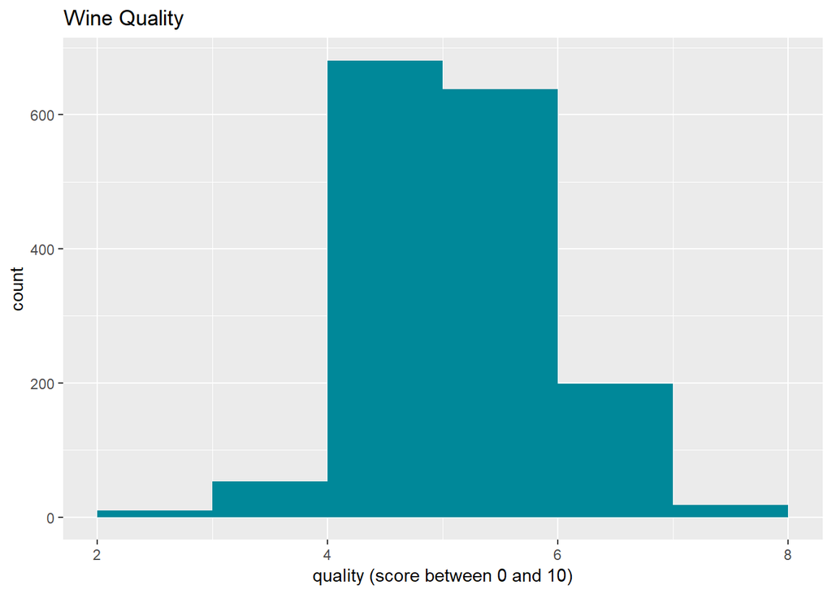

The quality of wines in this dataset is on average it is not very bad and in  
the same time it is not very good.

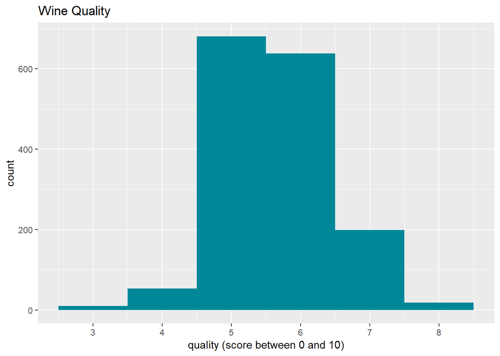

The above chart appears as a normal distribution, and that guides us to know  
the quality is on the average level, not perfect and not bad, and mean=5.64 median=6.00 and mode=5.00  
are close to the same each other

```
##    Min. 1st Qu.  Median    Mean 3rd Qu.    Max.
##   3.000   5.000   6.000   5.636   6.000   8.000
```

```
## [1] 5
```

*Resource: https://stackoverflow.com/questions/2547402/is-there-a-built-in-function-for-finding-the-mode ——————————————————————————-

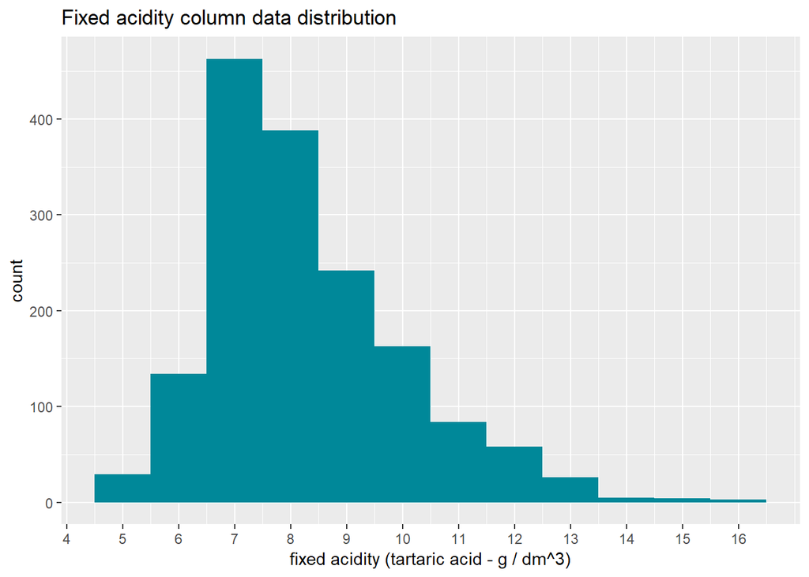

```
##    Min. 1st Qu.  Median    Mean 3rd Qu.    Max.
##    4.60    7.10    7.90    8.32    9.20   15.90
```

```
## [1] 7.2
```

Beacuse : mode < median < mean  
then: he is Right skewed.  
The chart in above apears to be positive -right- skewed, the mode is about 7,  
and the mode is on the left side of bar histogram and the bins in the left are  
very very small by this we know this is a positive skewed.  
From this chart, we notice most of the wines are have low fixed acidity.

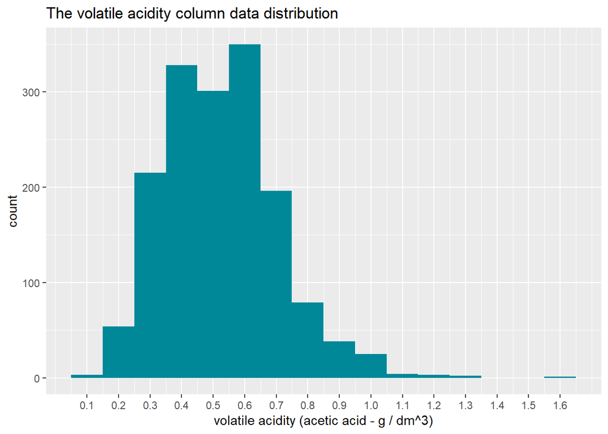

```
## [1] 0.6
```

```
##    Min. 1st Qu.  Median    Mean 3rd Qu.    Max.
##  0.1200  0.3900  0.5200  0.5278  0.6400  1.5800
```

Data distributions in statistics can have one peak, or they can have several peaks.  
The type of distribution you might be familiar with seeing is the normal distribution,  
or bell curve, which has one peak. The bimodal distribution has two peaks.  
What does a Bimodal Distribution tell you?  
You’ve got two peaks of data, which usually indicates you’ve got two different groups.*  
This can tell us that we are having at two different groups of wines, the first  
group is with low volatile acidity and the second group is with high volatile acidity.  
*Source:  
https://www.statisticshowto.datasciencecentral.com/what-is-a-bimodal-distribution/  
———————————————–

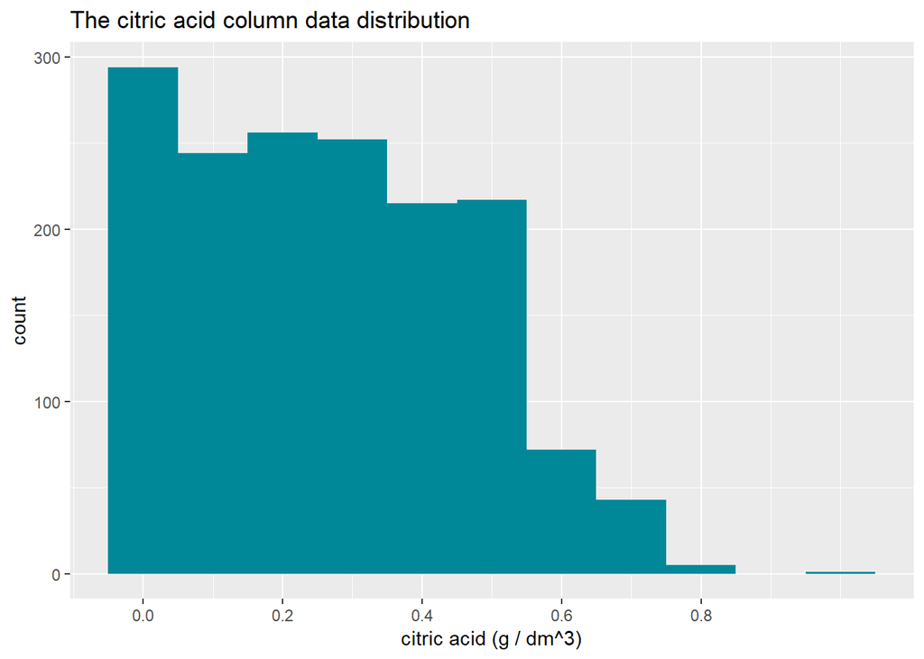

```
##    Min. 1st Qu.  Median    Mean 3rd Qu.    Max.
##   0.000   0.090   0.260   0.271   0.420   1.000
```

```
## [1] 0
```

Beacuse : mode < median < mean  
then: he is Right skewed.  
The chart in above apears to be positive -right- skewed, the mode is 0,  
and the mode is on the left side of bar histogram and the bins in the left are  
very small , and the data flow is oscillating between 0.1 and 0.5 and this guide us to notice  
those wines have the low or medium citric acid.  
—————————————————————————–

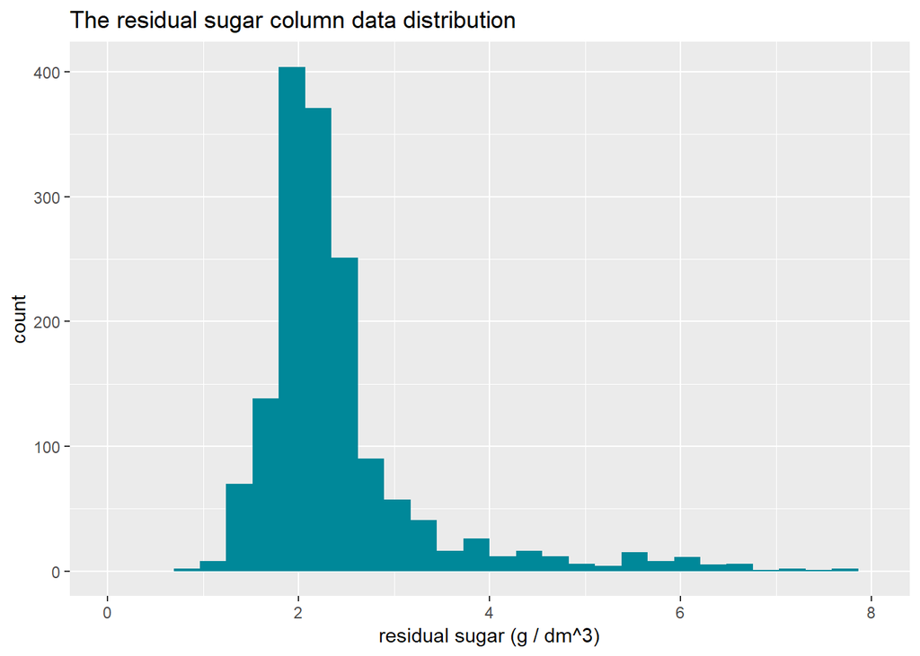

```
##    Min. 1st Qu.  Median    Mean 3rd Qu.    Max.
##   0.900   1.900   2.200   2.539   2.600  15.500
```

```
## [1] 2
```

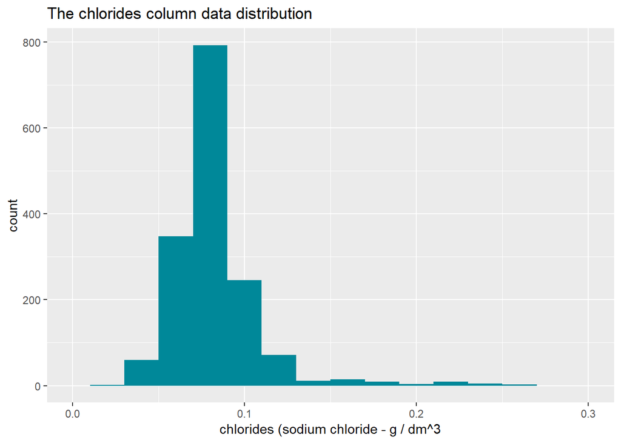

```
##    Min. 1st Qu.  Median    Mean 3rd Qu.    Max.
## 0.01200 0.07000 0.07900 0.08747 0.09000 0.61100
```

```
## [1] 0.08
```

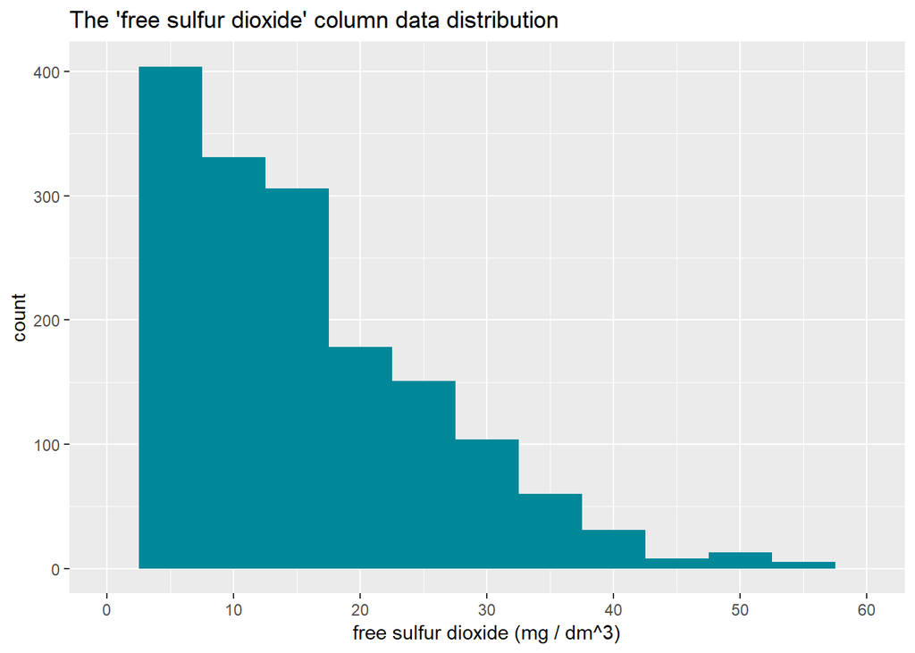

```
##    Min. 1st Qu.  Median    Mean 3rd Qu.    Max.
##    1.00    7.00   14.00   15.87   21.00   72.00
```

```
## [1] 6
```

Beacuse : mode < median < mean  
then: he is Right skewed.  
This histogram in above appears as positive skewed, most of the wines in this  
dataset are have a free sulfur dioxide between 5 and 25 mg / dm ^ 3,  
The benefit of this component is prevents microbial growth and the oxidation of wine.  
————————————————————————

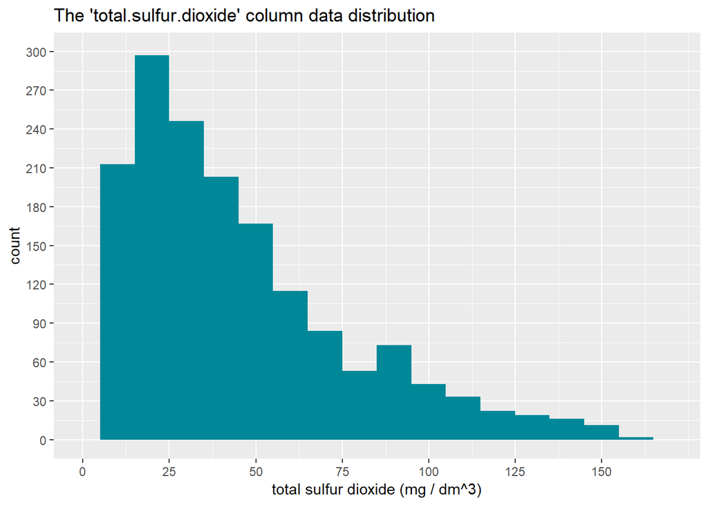

```
##    Min. 1st Qu.  Median    Mean 3rd Qu.    Max.
##    6.00   22.00   38.00   46.47   62.00  289.00
```

```
## [1] 28
```

Beacuse : mode < median < mean  
then: he is Right skewed.  
This histogram in above is also right skewed, and most of the wines in this dataset  
are score the total of sulfur dioxide less than 50 in the left side of histogram, and  
kind of wines SO2 becomes not evident in the nose and taste of wine*.*  
source:  
https://s3.amazonaws.com/udacity-hosted-downloads/ud651/wineQualityInfo.txt  
————————————————————-

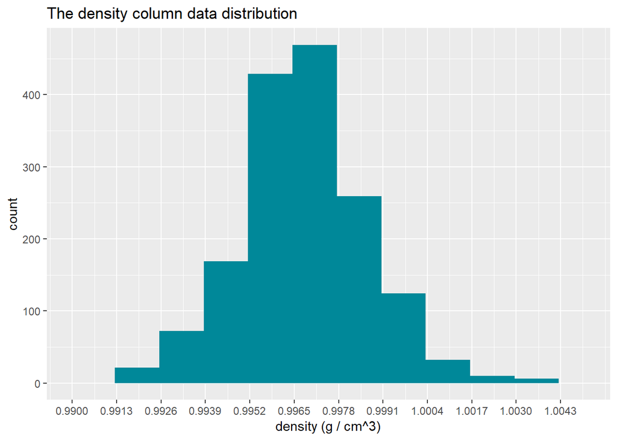

```
## [1] 0.9972
```

```
##    Min. 1st Qu.  Median    Mean 3rd Qu.    Max.
##  0.9901  0.9956  0.9968  0.9967  0.9978  1.0037
```

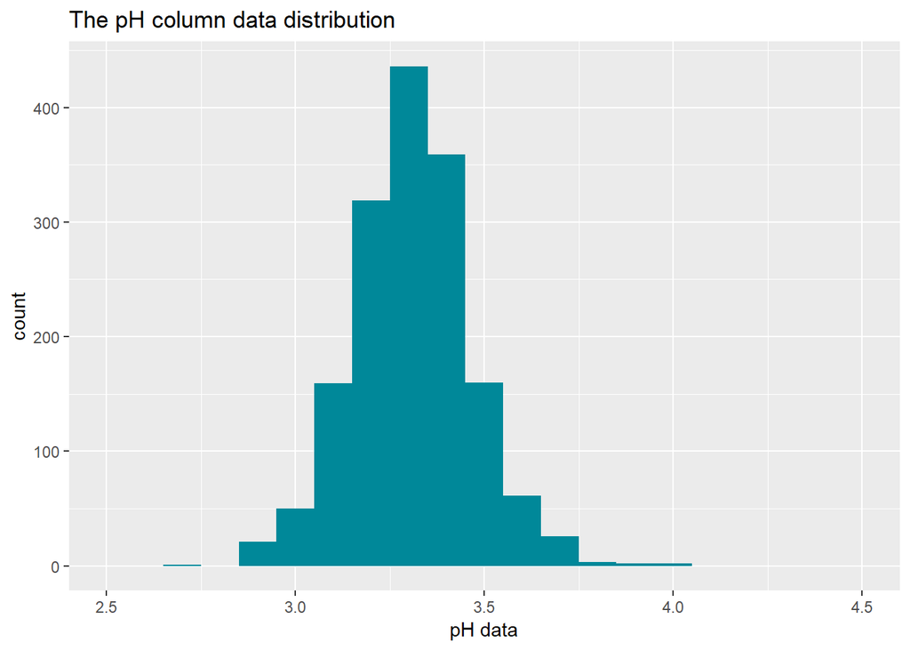

```
##    Min. 1st Qu.  Median    Mean 3rd Qu.    Max.
##   2.740   3.210   3.310   3.311   3.400   4.010
```

```
## [1] 3.3
```

Beacuse : mode = median = mean  
then: he is Normal Distribution.  
This histogram in above is normal distribution, Most of the wines in this  
dataset are acidic because pH is between 3 and 4 on the pH scale if pH near  
to 14 he will very basic*.*  
Source:  
https://s3.amazonaws.com/udacity-hosted-downloads/ud651/wineQualityInfo.txt  
———————————————————————–

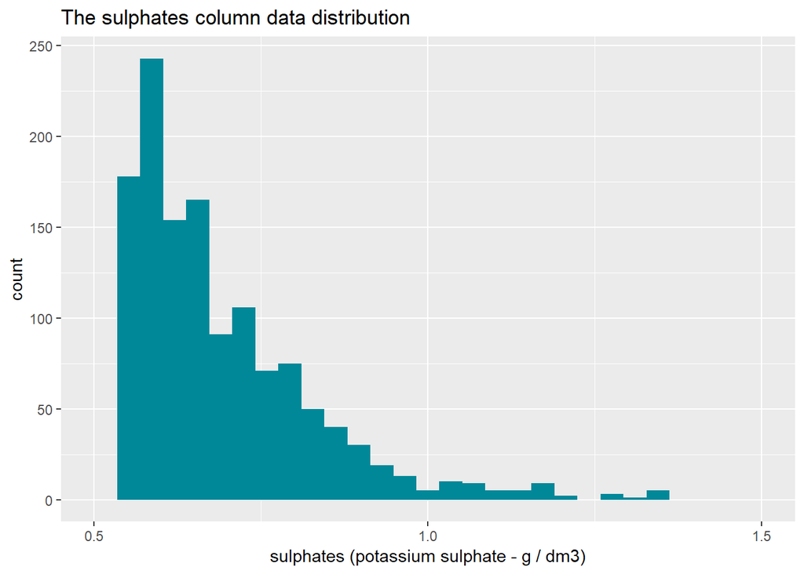

```
##    Min. 1st Qu.  Median    Mean 3rd Qu.    Max.
##  0.3300  0.5500  0.6200  0.6581  0.7300  2.0000
```

```
## [1] 0.6
```

Beacuse : mode < median < mean  
then: he is Right skewed.  
The spread of data in this column is positive-skew distributions That’s because  
there is a long tail in the positive direction on the number line. The mean is  
also to the right of the peak.  
Most of the wines in this dataset are have less than 1 g / dm3 from sulfates.  
Source:  
https://www.statisticshowto.datasciencecentral.com/probability-and-statistics/skewed-distribution/  
——————————————————————————

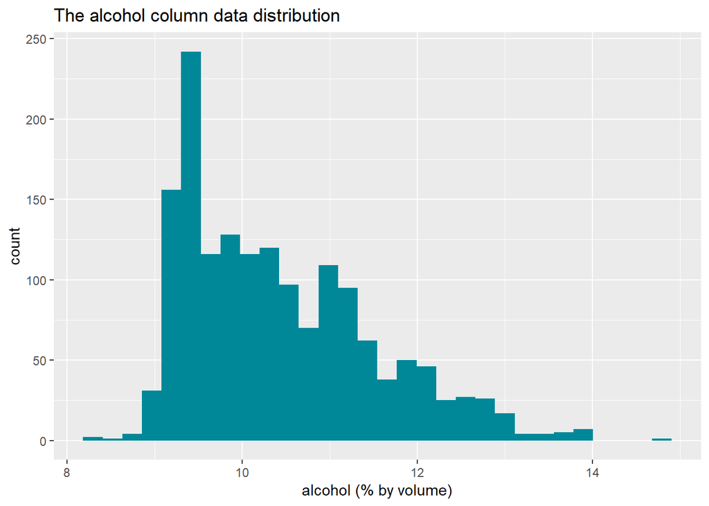

```
##    Min. 1st Qu.  Median    Mean 3rd Qu.    Max.
##    8.40    9.50   10.20   10.42   11.10   14.90
```

```
## [1] 9.5
```

### What is the structure of your dataset?

```
## 'data.frame':    1599 obs. of  12 variables:
##  $ fixed.acidity       : num  7.4 7.8 7.8 11.2 7.4 7.4 7.9 7.3 7.8 7.5 ...
##  $ volatile.acidity    : num  0.7 0.88 0.76 0.28 0.7 0.66 0.6 0.65 0.58 0.5 ...
##  $ citric.acid         : num  0 0 0.04 0.56 0 0 0.06 0 0.02 0.36 ...
##  $ residual.sugar      : num  1.9 2.6 2.3 1.9 1.9 1.8 1.6 1.2 2 6.1 ...
##  $ chlorides           : num  0.076 0.098 0.092 0.075 0.076 0.075 0.069 0.065 0.073 0.071 ...
##  $ free.sulfur.dioxide : num  11 25 15 17 11 13 15 15 9 17 ...
##  $ total.sulfur.dioxide: num  34 67 54 60 34 40 59 21 18 102 ...
##  $ density             : num  0.998 0.997 0.997 0.998 0.998 ...
##  $ pH                  : num  3.51 3.2 3.26 3.16 3.51 3.51 3.3 3.39 3.36 3.35 ...
##  $ sulphates           : num  0.56 0.68 0.65 0.58 0.56 0.56 0.46 0.47 0.57 0.8 ...
##  $ alcohol             : num  9.4 9.8 9.8 9.8 9.4 9.4 9.4 10 9.5 10.5 ...
##  $ quality             : int  5 5 5 6 5 5 5 7 7 5 ...
```

As we seen in the above table of the structure of this dataset, we have 13  
variables minus 1 column his called ‘X’ we don’t need in our analysis because  
he is a serial number.  
And the number of observations is 1599.  
All of the variables are from quantitative continues type because it is could be  
divided and reduced to finer and finer levels* except quality column he is from quantitative discrete type, discrete have finite values or buckets**.  
*http://blog.minitab.com/blog/understanding-statistics/understanding-qualitative-quantitative-attribute-discrete-and-continuous-data-types  
**http://www.usablestats.com/lessons/datatypes2  
————————————–

### What is/are the main feature(s) of interest in your dataset?

All of the features are interesting for me, but the quality variable is very important because we can play with him to study the relation between wines quality and the other variables like density, alcohol, etc.

| ### What other features in the dataset do you think will help support your investigation into your feature(s) of interest? |
| --- |
| Maybe percent of alcohol in wines of this dataset and studying his relation with other variable. |

### Did you create any new variables from existing variables in the dataset?

No not yet, but I think I will create one variable called rate of the quality.

### Of the features you investigated, were there any unusual distributions? Did you perform any operations on the data to tidy, adjust, or change the form of the data? If so, why did you do this?

There are no unusual distributions, and I didn’t perform any operations on the data to tidy, adjust, or change the form of the data yet, but maybe will make some operations in the next investigations.

# Bivariate Plots Section

To know the correlation between all variables I will use corrplot function.

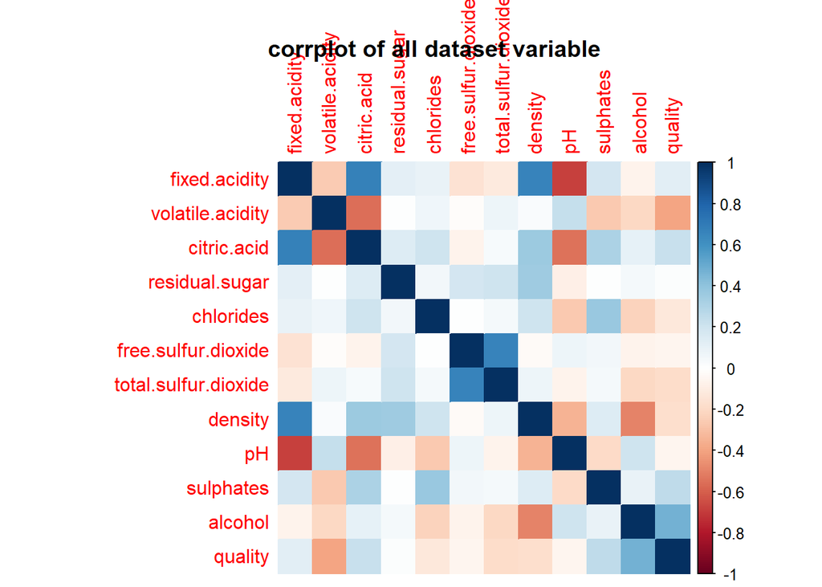

`## numeric(0)`

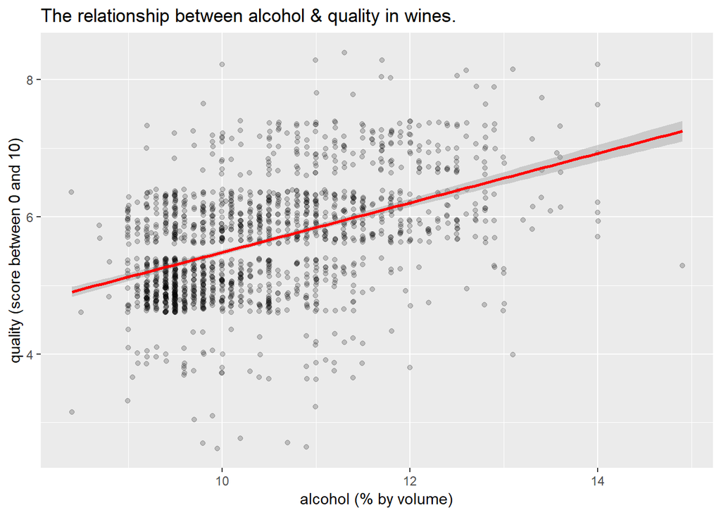

This scatter plot in above shows us the relationship between alcohol and the quality of  
wines, and this relationship is a positive. from this plot we know that if the  
alcohol level is high the quality will be high.

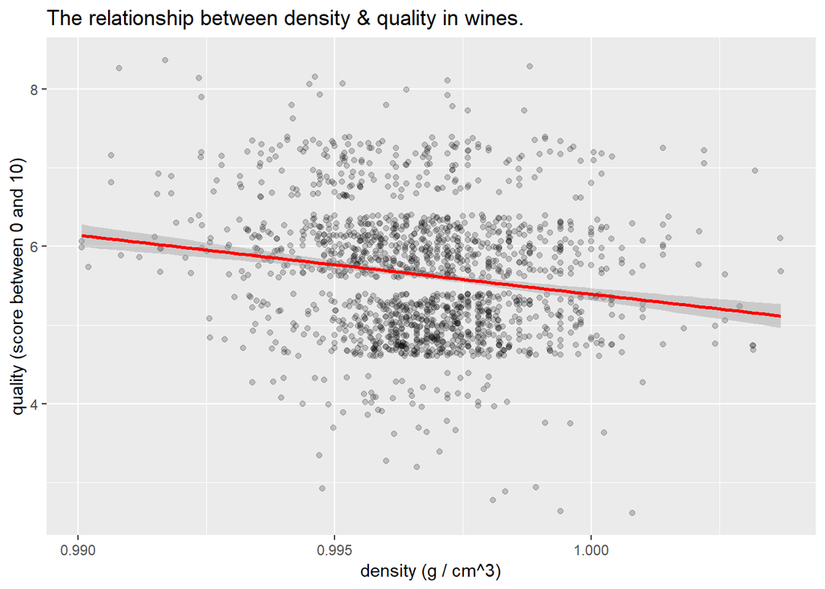

This scatter plot in above shows us the relationship between density and the quality of  
wines, and this relationship is a negative. from this plot we know that if the  
density is high the quality will be low.

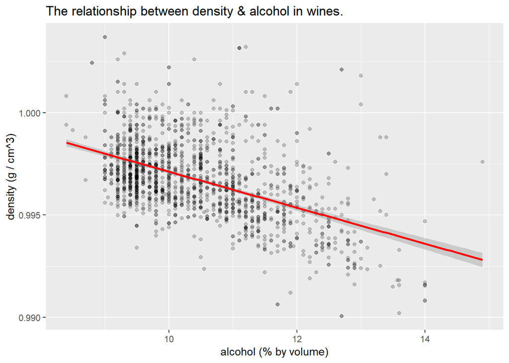

This scatter plot in above shows us the relationship between density and the alcohol in the  
wines, and this relationship is a negative. from this plot we know that if the  
alcohol level is high the density will be low.

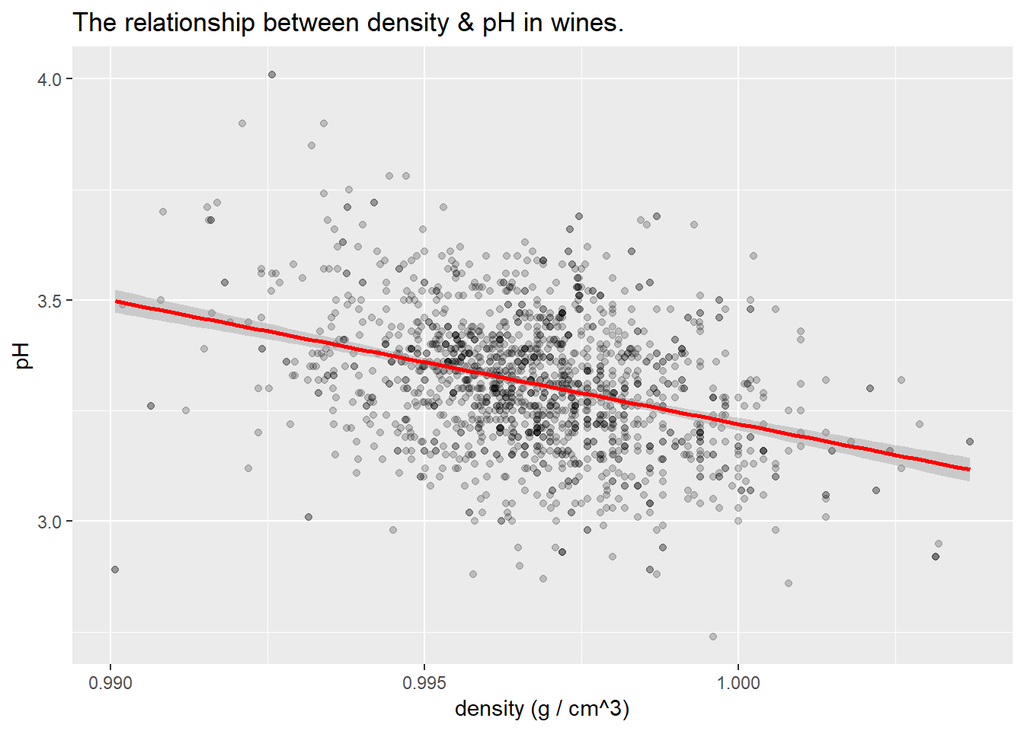

This scatter plot in above shows us the relationship between density and the pH -defined  
as the negative Logarithm of molar concentration of Hydrogen ions*- in the  
wines, and this relationship is a negative. from this plot we know that if the  
density is high the pH level will be low.

Source:  
https://en.wikipedia.org/wiki/PH

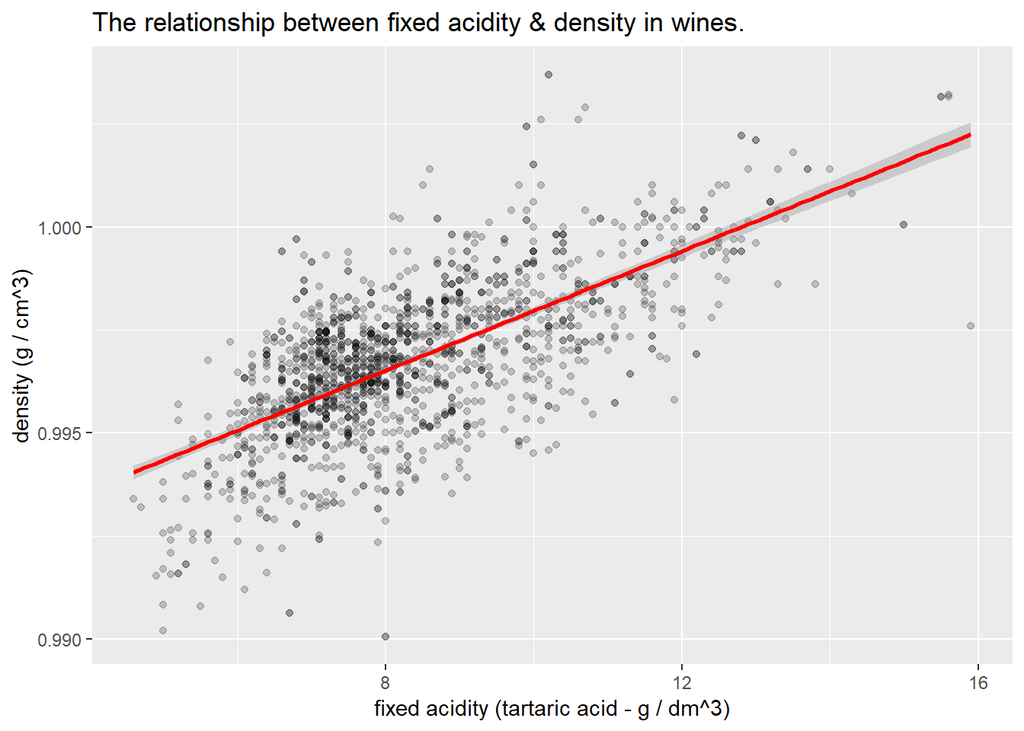

This scatter plot in above shows us the relationship between density and the fixed acidity in the  
wines, and this relationship is a positive. from this plot we know that if the  
fixed acidity level is high the density will be high.

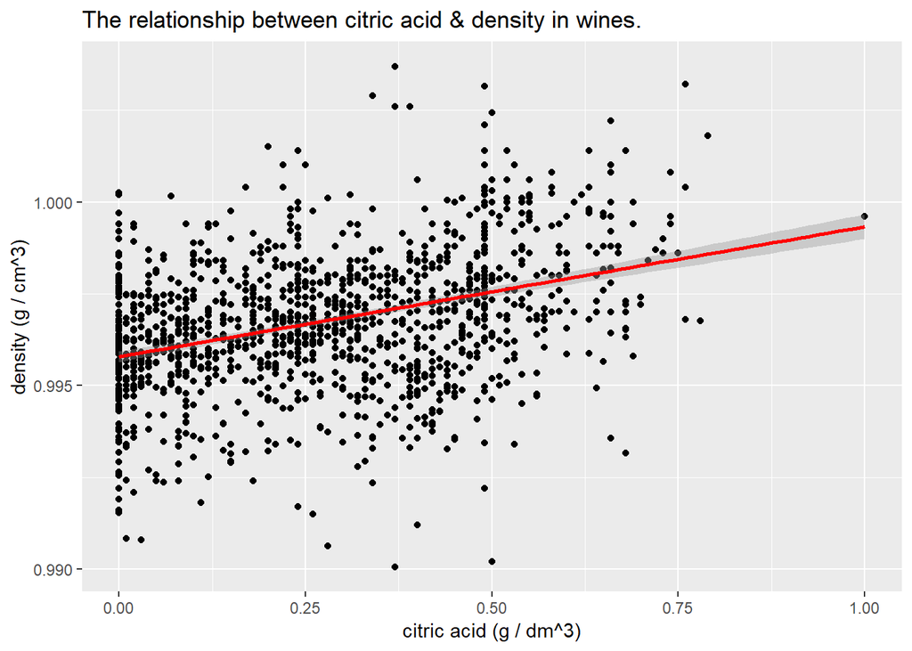

This scatter plot in above shows us the relationship between density and the citric acid in the  
wines, and this relationship is a positive. from this plot we know that if the  
citric acid level is high the density will be high.

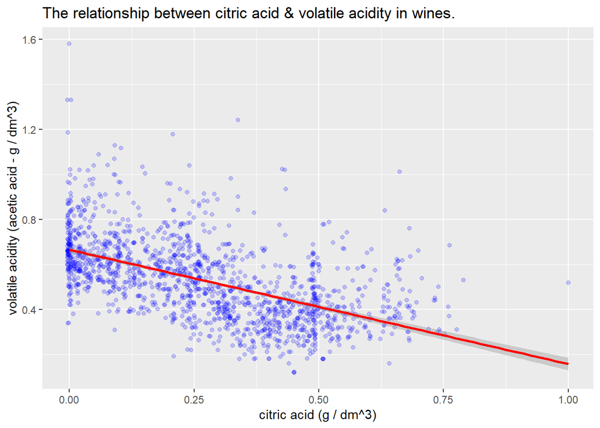

This scatter plot in above shows us the relationship between citric acid and the  
volatile acidity in the wines, and this relationship is a negative. from this  
plot we know that if the citric acid level is high the volatile acidity will be low.

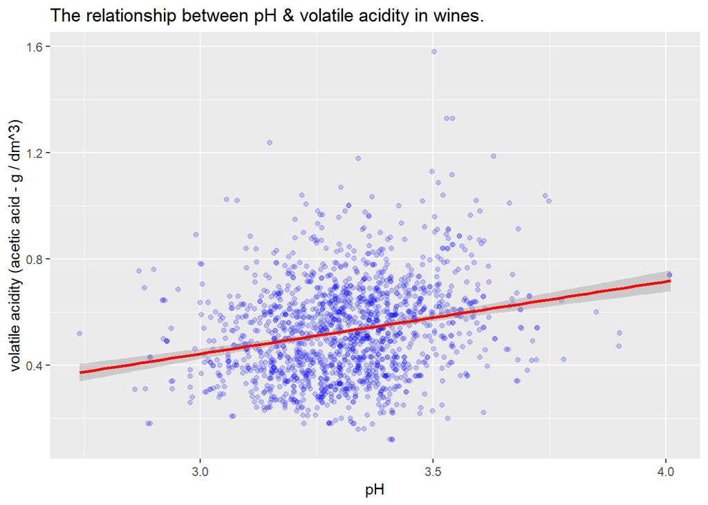

This scatter plot in above shows us the relationship between pH and the volatile acidity in the  
wines, and this relationship is a positive. from this plot we know that if the  
pH level is high the volatile acidity will be high.

# Bivariate Analysis

### Talk about some of the relationships you observed in this part of the  
investigation. How did the feature(s) of interest vary with other features in  
the dataset?

I have enjoyed work with this dataset because it needs to investigate before making  
any decision when I studied the relationship between some variables I notice there  
is some variable need to some exploring to see which kind of relation does it have  
with another variable, and I took some samples from those variables and see where  
are the data are heading.

### Did you observe any interesting relationships between the other features  
(not the main feature(s) of interest)?

# Multivariate Plots Section

craete a new variable called classify

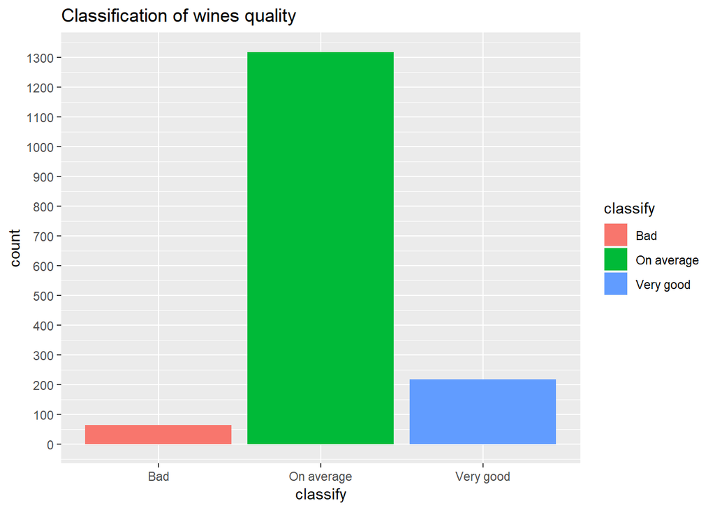

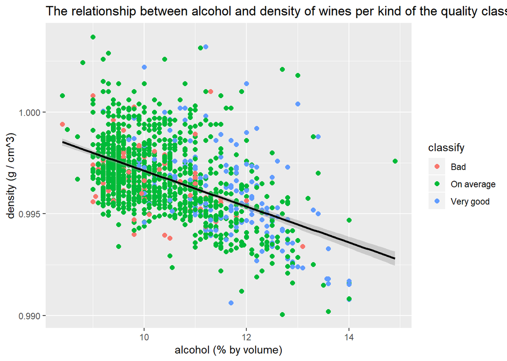

# Multivariate Analysis

### Talk about some of the relationships you observed in this part of the  
investigation. Were there features that strengthened each other in terms of  
looking at your feature(s) of interest?

### Were there any interesting or surprising interactions between features?

Yes, if the quality is very good we can guess the volume of alcohol it will be  
high.  
### OPTIONAL: Did you create any models with your dataset? Discuss the  
strengths and limitations of your model.

# Final Plots and Summary

### Plot One

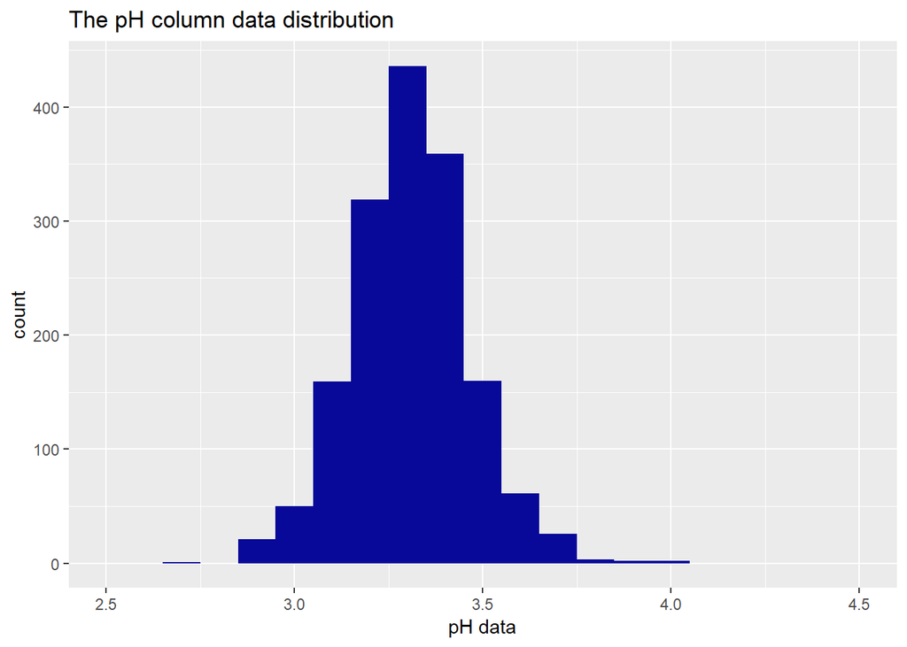

### Description One

This histogram in above is normal distribution, Most of the wines in this  
dataset are acidic because pH is between 3 and 4 on the pH scale if pH near  
to 14 he will very basic*.*  
Source:  
https://s3.amazonaws.com/udacity-hosted-downloads/ud651/wineQualityInfo.txt

### Plot Two

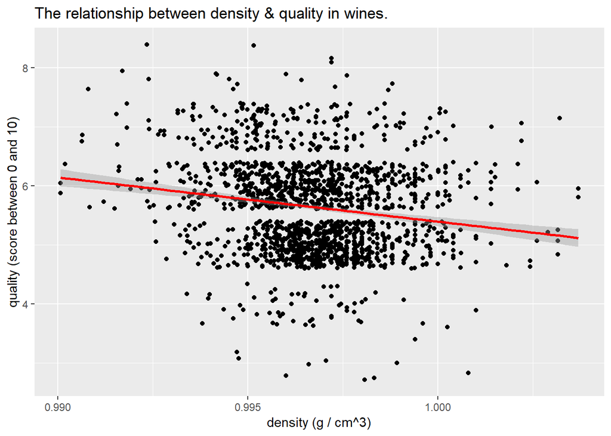

```
##
##  Pearson's product-moment correlation
##
## data:  wr$quality and wr$density
## t = -7.0997, df = 1597, p-value = 1.875e-12
## alternative hypothesis: true correlation is not equal to 0
## 95 percent confidence interval:
##  -0.2220365 -0.1269870
## sample estimates:
##        cor
## -0.1749192
```

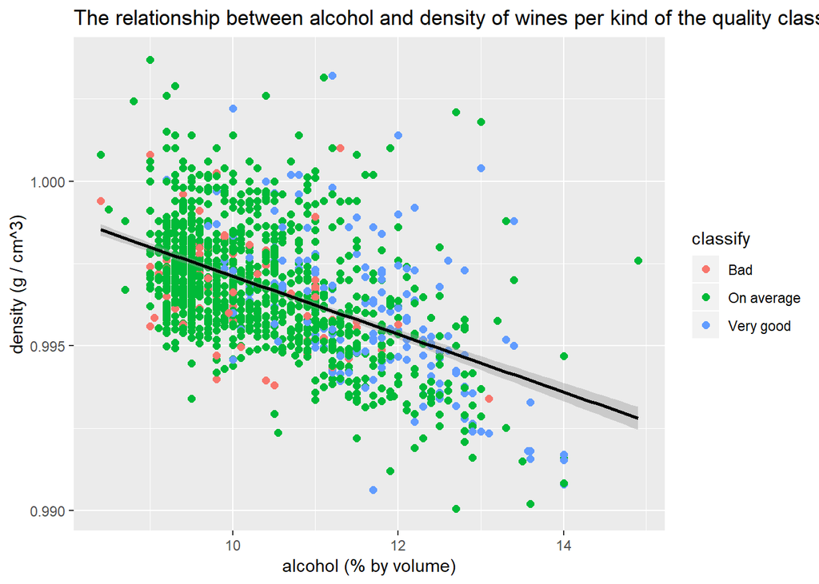

# Reflection

I didn’t find any difficulty in this dataset except when I studied the relationships  
between quality and other variables, I used scatter plot but the relationships were  
not very clear and I tried to take some sample to see the direction of the data and the  
relationship.

I have a multi ideas I want to do it by my knowledge I have by this course, like  
analysis the data of my department in my work.